# Study Case 3 - Clustering, Classification, and Prediction of House Pricing in Paris

IS388A - A2 Group

November 2021

## 0.1 Loading Library

## 0.2 Preparing and Cleaning Data

“Paris Housing” data description.

The following is a data about the pricing of houses in Paris based on the house specification or conditions We obtained this data from Kaggle (https://www.kaggle.com/aleshagavrilov/parishousing)

The dataset consists of 18 variables which are :

1. Index : The index/numbering of the data (which we will remove later because we don’t need it)
2. Square Meters (squareMeters) : Area if the apartment in square meters
3. Number of Rooms (numberOfRooms) : Number of rooms in the apartment
4. Floors (floors) : The amount of floors in the house
5. City Code (cityCode) : Code of the city, where the apartment situated
6. City Part Range (cityPartRange) : Prestige of the area in range from 0 to 10
7. Number of Previous Owners (numPrevOwners) : Number of previous owners
8. Made (made) : The year when house was built
9. New Built (isNewBuilt) : The aparment is new or renovated
10. Storm Protector (hasStormProtector) : Apartment has storm protector or not
11. Basement (basement) : The apartment has basement or not (in square meters)
12. Attic (attic) : The apartment has attic or not (in square meters)
13. Garage (garage) : The apartment has garage or not (in square meters)
14. Storage Room (hasStorageRoom) : The apartment has storage room or not
15. Guest Room (hasGuestRoom) : The number of guest room in the apartment
16. Price (price) : The price of the apartment
17. Category (category) : Category of the house
18. Pool and Yard (poolAndYard) : The apartment has pool and yard or not

The purpose of this project is to build clustering, classification, and prediction model of House Pricing in Paris using their respective algorithms.

```r
#--------------------------Data Introduction--------------------------
# Reading dataset and saving it into 'A2' variable
A2 <- read_excel("CS3_A2.xlsx", sheet = "CS3_A2")

# Checking the structure of the data
str(A2)
```

```
## tibble [10,000 x 17] (S3: tbl_df/tbl/data.frame)
##  $ squareMeters     : num [1:10000] 75523 80771 55712 32316 70429 ...
##  $ numberOfRooms    : num [1:10000] 3 39 58 47 19 36 10 100 3 42 ...
##  $ floors           : num [1:10000] 63 98 19 6 90 17 99 11 61 15 ...
##  $ cityCode         : num [1:10000] 9373 39381 34457 27939 38045 ...
##  $ cityPartRange    : num [1:10000] 3 8 6 10 3 8 10 3 8 5 ...
##  $ numPrevOwners    : num [1:10000] 8 6 8 4 7 6 9 4 3 8 ...
##  $ made             : num [1:10000] 2005 2015 2021 2012 1990 ...
##  $ isNewBuilt       : chr [1:10000] "False" "True" "False" "False" ...
##  $ hasStormProtector: chr [1:10000] "True" "False" "False" "True" ...
##  $ basement         : num [1:10000] 4313 3653 2937 659 8435 ...
##  $ attic            : num [1:10000] 9005 2436 8852 7141 2429 ...
##  $ garage           : num [1:10000] 956 128 135 359 292 757 848 654 807 591 ...
##  $ hasStorageRoom   : chr [1:10000] "False" "True" "True" "False" ...
##  $ hasGuestRoom     : num [1:10000] 7 2 9 3 4 1 5 10 5 3 ...
##  $ price            : num [1:10000] 7559082 8085990 5574642 3232561 7055052 ...
##  $ category         : chr [1:10000] "Basic" "Luxury" "Basic" "Basic" ...
##  $ poolAndYard      : chr [1:10000] "has pool and no yard" "has pool and has yard" "has pool and no yard" "no pool and no yard" ...
```

```r
# Displaying the first few rows of the data
head(A2)
```

```
## # A tibble: 6 x 17
##   squareMeters numberOfRooms floors cityCode cityPartRange numPrevOwners  made
##          <dbl>         <dbl>  <dbl>    <dbl>         <dbl>         <dbl> <dbl>
## 1        75523             3     63     9373             3             8  2005
## 2        80771            39     98    39381             8             6  2015
## 3        55712            58     19    34457             6             8  2021
## 4        32316            47      6    27939            10             4  2012
## 5        70429            19     90    38045             3             7  1990
## 6        39223            36     17    39489             8             6  2012
## # ... with 10 more variables: isNewBuilt <chr>, hasStormProtector <chr>,
## #   basement <dbl>, attic <dbl>, garage <dbl>, hasStorageRoom <chr>,
## #   hasGuestRoom <dbl>, price <dbl>, category <chr>, poolAndYard <chr>
```

```r
# Showing the summary of the data
summary(A2)
```

```
##   squareMeters   numberOfRooms        floors          cityCode
##  Min.   :   89   Min.   :  1.00   Min.   :  1.00   Min.   :    3
##  1st Qu.:25099   1st Qu.: 25.00   1st Qu.: 25.00   1st Qu.:24694
##  Median :50106   Median : 51.00   Median : 50.00   Median :50693
##  Mean   :49870   Mean   : 50.57   Mean   : 50.28   Mean   :50225
##  3rd Qu.:74610   3rd Qu.: 75.00   3rd Qu.: 76.00   3rd Qu.:75683
##  Max.   :99999   Max.   :100.00   Max.   :100.00   Max.   :99953
##  cityPartRange   numPrevOwners         made       isNewBuilt
##  Min.   : 1.00   Min.   : 1.000   Min.   :1990   Length:10000
##  1st Qu.: 3.00   1st Qu.: 3.000   1st Qu.:1997   Class :character
##  Median : 5.00   Median : 5.000   Median :2006   Mode  :character
##  Mean   : 5.51   Mean   : 5.522   Mean   :2005
##  3rd Qu.: 8.00   3rd Qu.: 8.000   3rd Qu.:2014
##  Max.   :10.00   Max.   :10.000   Max.   :2021
##  hasStormProtector     basement         attic           garage
##  Length:10000       Min.   :    0   Min.   :    1   Min.   : 100.0
##  Class :character   1st Qu.: 2560   1st Qu.: 2512   1st Qu.: 327.8
##  Mode  :character   Median : 5092   Median : 5045   Median : 554.0
##                     Mean   : 5033   Mean   : 5028   Mean   : 553.1
##                     3rd Qu.: 7511   3rd Qu.: 7540   3rd Qu.: 777.2
##                     Max.   :10000   Max.   :10000   Max.   :1000.0
##  hasStorageRoom      hasGuestRoom        price            category
##  Length:10000       Min.   : 0.000   Min.   :   10314   Length:10000
##  Class :character   1st Qu.: 2.000   1st Qu.: 2516402   Class :character
##  Mode  :character   Median : 5.000   Median : 5016180   Mode  :character
##                     Mean   : 4.995   Mean   : 4993448
##                     3rd Qu.: 8.000   3rd Qu.: 7469092
##                     Max.   :10.000   Max.   :10006771
##  poolAndYard
##  Length:10000
##  Class :character
##  Mode  :character
##
##
##
```

```r
#------------------------Handling Missing Data------------------------
# Checking missing values (missing values or empty values) before Omitting NAs
colSums(is.na(A2) | A2 == '')
```

```
##      squareMeters     numberOfRooms            floors          cityCode
##                 0                 0                 0                 0
##     cityPartRange     numPrevOwners              made        isNewBuilt
##                 0                 0                 0                 0
## hasStormProtector          basement             attic            garage
##                 0                 0                 0                 0
##    hasStorageRoom      hasGuestRoom             price          category
##                 0                 0                 0                 0
##       poolAndYard
##                 0
```

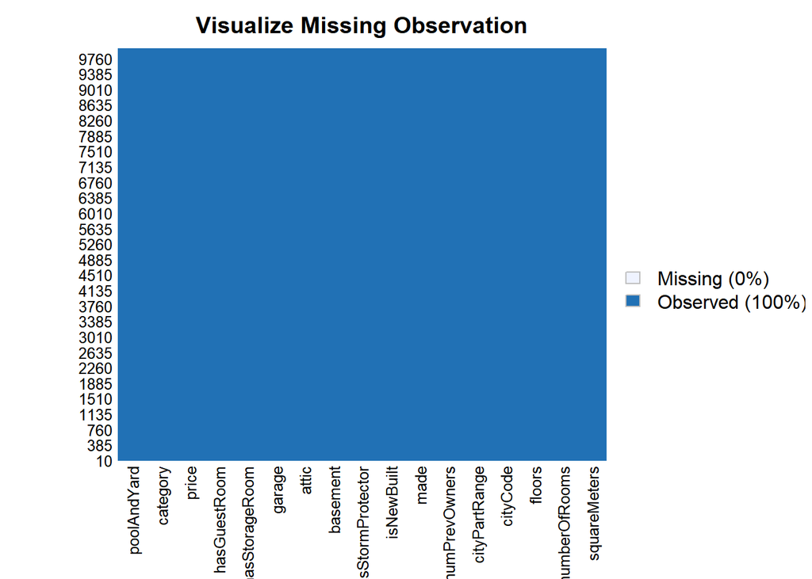

```r
# Visualize the missing data before Omitting NAs
missmap(A2, legend = TRUE, main = "Visualize Missing Observation")
```

```r
# In this data, there isn't any missing values.

#----------------------Eliminate Duplicate Data-----------------------
A2 <- distinct(A2)
str(A2)
```

```
## tibble [10,000 x 17] (S3: tbl_df/tbl/data.frame)
##  $ squareMeters     : num [1:10000] 75523 80771 55712 32316 70429 ...
##  $ numberOfRooms    : num [1:10000] 3 39 58 47 19 36 10 100 3 42 ...
##  $ floors           : num [1:10000] 63 98 19 6 90 17 99 11 61 15 ...
##  $ cityCode         : num [1:10000] 9373 39381 34457 27939 38045 ...
##  $ cityPartRange    : num [1:10000] 3 8 6 10 3 8 10 3 8 5 ...
##  $ numPrevOwners    : num [1:10000] 8 6 8 4 7 6 9 4 3 8 ...
##  $ made             : num [1:10000] 2005 2015 2021 2012 1990 ...
##  $ isNewBuilt       : chr [1:10000] "False" "True" "False" "False" ...
##  $ hasStormProtector: chr [1:10000] "True" "False" "False" "True" ...
##  $ basement         : num [1:10000] 4313 3653 2937 659 8435 ...
##  $ attic            : num [1:10000] 9005 2436 8852 7141 2429 ...
##  $ garage           : num [1:10000] 956 128 135 359 292 757 848 654 807 591 ...
##  $ hasStorageRoom   : chr [1:10000] "False" "True" "True" "False" ...
##  $ hasGuestRoom     : num [1:10000] 7 2 9 3 4 1 5 10 5 3 ...
##  $ price            : num [1:10000] 7559082 8085990 5574642 3232561 7055052 ...
##  $ category         : chr [1:10000] "Basic" "Luxury" "Basic" "Basic" ...
##  $ poolAndYard      : chr [1:10000] "has pool and no yard" "has pool and has yard" "has pool and no yard" "no pool and no yard" ...
```

```r
#------------------------Manipulating Data Type-----------------------
# Discard the unused categorical variables.
A2_new <- A2 %>% dplyr :: select (-cityCode, -cityPartRange, -isNewBuilt, -hasStorageRoom, -hasStormProtector, -poolAndYard)
# Because, these are the categorical variables we don't need in clustering the data.

# Changing the char data type as factor
#----- category variable
A2_new$category <- as.factor(A2_new$category)
A2_new$category <- factor(A2_new$category, levels = c("Basic", "Luxury"))

# We need the category to validate the clustering model.

# Checking the class of each variable in the data (data type) after discarding some variables and changing char to factor
str(A2_new)
```

```
## tibble [10,000 x 11] (S3: tbl_df/tbl/data.frame)
##  $ squareMeters : num [1:10000] 75523 80771 55712 32316 70429 ...
##  $ numberOfRooms: num [1:10000] 3 39 58 47 19 36 10 100 3 42 ...
##  $ floors       : num [1:10000] 63 98 19 6 90 17 99 11 61 15 ...
##  $ numPrevOwners: num [1:10000] 8 6 8 4 7 6 9 4 3 8 ...
##  $ made         : num [1:10000] 2005 2015 2021 2012 1990 ...
##  $ basement     : num [1:10000] 4313 3653 2937 659 8435 ...
##  $ attic        : num [1:10000] 9005 2436 8852 7141 2429 ...
##  $ garage       : num [1:10000] 956 128 135 359 292 757 848 654 807 591 ...
##  $ hasGuestRoom : num [1:10000] 7 2 9 3 4 1 5 10 5 3 ...
##  $ price        : num [1:10000] 7559082 8085990 5574642 3232561 7055052 ...
##  $ category     : Factor w/ 2 levels "Basic","Luxury": 1 2 1 1 2 1 2 1 1 1 ...
```

```r
sapply(A2_new, class)
```

```
##  squareMeters numberOfRooms        floors numPrevOwners          made
##     "numeric"     "numeric"     "numeric"     "numeric"     "numeric"
##      basement         attic        garage  hasGuestRoom         price
##     "numeric"     "numeric"     "numeric"     "numeric"     "numeric"
##      category
##      "factor"
```

```r
# the new data frame only consists of numerical variables and one categorical variables which is category to validate the clustering models.
```

## 0.3 Data Visualization; Exploratory Data Analysis

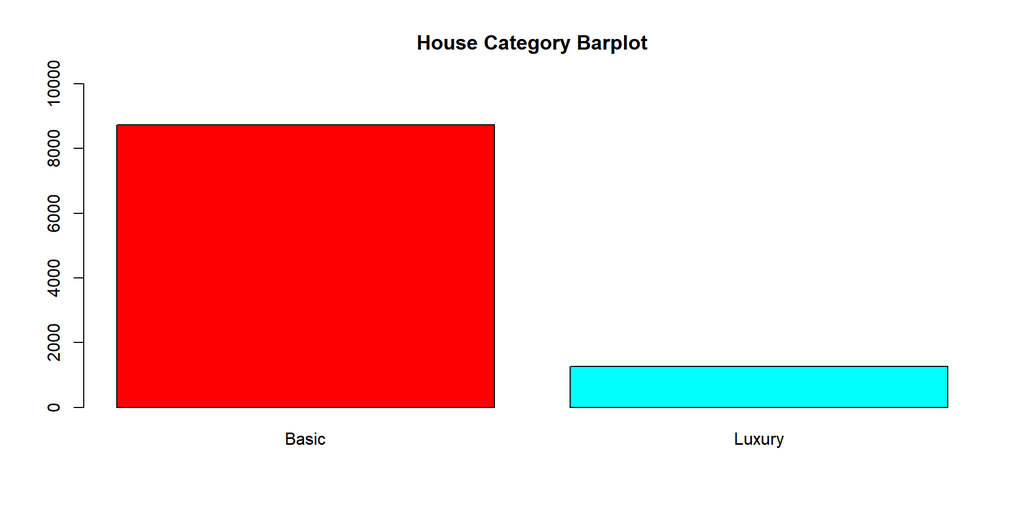

```r
#----------------------------Visualization----------------------------
# Categorical type ---------------------------------------------------
tab1 <-table(A2_new$category)
barplot(tab1, main = "House Category Barplot", col = rainbow(2), ylim = c(0,10000))
```

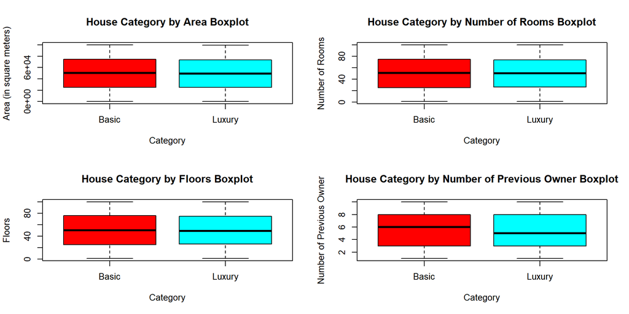

```r
# CONCLUSION : the frequency of basic is higher than the frequency of luxury house category.

# Categorical x Numerical type ---------------------------------------
par(mfrow = c(2,2))

bx1 <- boxplot(A2_new$squareMeters ~ A2_new$category, main = "House Category by Area Boxplot", xlab = "Category", ylab = "Area (in square meters)", col = rainbow(2))

bx2 <- boxplot(A2_new$numberOfRooms ~ A2_new$category, main = "House Category by Number of Rooms Boxplot", xlab = "Category", ylab = "Number of Rooms", col = rainbow(2))

bx3 <- boxplot(A2_new$floors ~ A2_new$category, main = "House Category by Floors Boxplot", xlab = "Category", ylab = "Floors", col = rainbow(2))

bx4 <- boxplot(A2_new$numPrevOwners ~ A2_new$category, main = "House Category by Number of Previous Owner Boxplot", xlab = "Category", ylab = "Number of Previous Owner", col = rainbow(2))
```

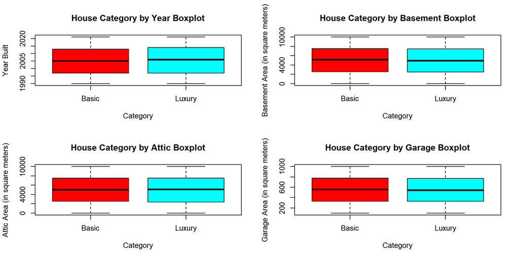

```r
bx5 <- boxplot(A2_new$made ~ A2_new$category, main = "House Category by Year Boxplot", xlab = "Category", ylab = "Year Built", col = rainbow(2))

bx6 <- boxplot(A2_new$basement ~ A2_new$category, main = "House Category by Basement Boxplot", xlab = "Category", ylab = "Basement Area (in square meters)", col = rainbow(2))

bx7 <- boxplot(A2_new$attic ~ A2_new$category, main = "House Category by Attic Boxplot", xlab = "Category", ylab = "Attic Area (in square meters)", col = rainbow(2))

bx8 <- boxplot(A2_new$garage ~ A2_new$category, main = "House Category by Garage Boxplot", xlab = "Category", ylab = "Garage Area (in square meters)", col = rainbow(2))
```

```r
bx9 <- boxplot(A2_new$hasGuestRoom ~ A2_new$category, main = "House Category by Guest Room Boxplot", xlab = "Category", ylab = "Guest Room", col = rainbow(2))

bx10 <- boxplot(A2_new$price ~ A2_new$category, main = "House Category by Price Boxplot", xlab = "Category", ylab = "Price", col = rainbow(2))

# CONCLUSION : All the boxplots for house category vs numerical variables are mostly similar between the basic and the luxury type.

# Checking the stats
# stats: each column represents the lower whisker, the first quartile, the median, the third quartile and the upper whisker of each group.
bx1$`stats`
```

```
##         [,1]  [,2]
## [1,]    89.0   152
## [2,] 25072.0 25204
## [3,] 50185.0 49116
## [4,] 74702.5 73719
## [5,] 99999.0 99750
```

```r
bx2$`stats`
```

```
##      [,1] [,2]
## [1,]    1    1
## [2,]   25   26
## [3,]   51   50
## [4,]   75   74
## [5,]  100  100
```

```r
bx3$`stats`
```

```
##      [,1] [,2]
## [1,]    1    1
## [2,]   25   26
## [3,]   50   49
## [4,]   76   75
## [5,]  100  100
```

```r
bx4$`stats`
```

```
##      [,1] [,2]
## [1,]    1    1
## [2,]    3    3
## [3,]    6    5
## [4,]    8    8
## [5,]   10   10
```

```r
bx5$`stats`
```

```
##      [,1] [,2]
## [1,] 1990 1990
## [2,] 1997 1997
## [3,] 2005 2006
## [4,] 2013 2014
## [5,] 2021 2021
```

```r
bx6$`stats`
```

```
##         [,1] [,2]
## [1,]     1.0    0
## [2,]  2570.5 2464
## [3,]  5121.0 4916
## [4,]  7520.5 7433
## [5,] 10000.0 9996
```

```r
bx7$`stats`
```

```
##         [,1] [,2]
## [1,]     1.0    8
## [2,]  2540.0 2364
## [3,]  5044.0 5070
## [4,]  7542.5 7534
## [5,] 10000.0 9994
```

```r
bx8$`stats`
```

```
##      [,1] [,2]
## [1,]  100  102
## [2,]  327  328
## [3,]  556  543
## [4,]  778  773
## [5,] 1000 1000
```

```r
bx9$`stats`
```

```
##      [,1] [,2]
## [1,]    0    0
## [2,]    2    2
## [3,]    5    5
## [4,]    8    8
## [5,]   10   10
```

```r
bx10$`stats`
```

```
##            [,1]      [,2]
## [1,]    10313.5   22160.2
## [2,]  2515468.4 2530488.0
## [3,]  5023160.6 4923159.3
## [4,]  7476689.0 7382091.9
## [5,] 10006771.2 9984910.3
```

```r
# Checking the outlier
bx1$out
```

```
## numeric(0)
```

```r
bx2$out
```

```
## numeric(0)
```

```r
bx3$out
```

```
## numeric(0)
```

```r
bx4$out
```

```
## numeric(0)
```

```r
bx5$out
```

```
## numeric(0)
```

```r
bx6$out
```

```
## numeric(0)
```

```r
bx7$out
```

```
## numeric(0)
```

```r
bx8$out
```

```
## numeric(0)
```

```r
bx9$out
```

```
## numeric(0)
```

```r
bx10$out
```

```
## numeric(0)
```

```r
# Anderson-Darling test to check whether the distribution is Gaussian
nortest::ad.test(A2_new$squareMeters)
```

```
##
##  Anderson-Darling normality test
##
## data:  A2_new$squareMeters
## A = 105.68, p-value < 2.2e-16
```

```r
nortest::ad.test(A2_new$numberOfRooms)
```

```
##
##  Anderson-Darling normality test
##
## data:  A2_new$numberOfRooms
## A = 102.28, p-value < 2.2e-16
```

```r
nortest::ad.test(A2_new$floors)
```

```
##
##  Anderson-Darling normality test
##
## data:  A2_new$floors
## A = 112.46, p-value < 2.2e-16
```

```r
nortest::ad.test(A2_new$numPrevOwners)
```

```
##
##  Anderson-Darling normality test
##
## data:  A2_new$numPrevOwners
## A = 168.18, p-value < 2.2e-16
```

```r
nortest::ad.test(A2_new$made)
```

```
##
##  Anderson-Darling normality test
##
## data:  A2_new$made
## A = 124.09, p-value < 2.2e-16
```

```r
nortest::ad.test(A2_new$basement)
```

```
##
##  Anderson-Darling normality test
##
## data:  A2_new$basement
## A = 105.22, p-value < 2.2e-16
```

```r
nortest::ad.test(A2_new$attic)
```

```
##
##  Anderson-Darling normality test
##
## data:  A2_new$attic
## A = 113.51, p-value < 2.2e-16
```

```r
nortest::ad.test(A2_new$garage)
```

```
##
##  Anderson-Darling normality test
##
## data:  A2_new$garage
## A = 115.79, p-value < 2.2e-16
```

```r
nortest::ad.test(A2_new$hasGuestRoom)
```

```
##
##  Anderson-Darling normality test
##
## data:  A2_new$hasGuestRoom
## A = 167.19, p-value < 2.2e-16
```

```r
nortest::ad.test(A2_new$price)
```

```
##
##  Anderson-Darling normality test
##
## data:  A2_new$price
## A = 105.68, p-value < 2.2e-16
```

```r
# Result : all the p-value < alpha (0.05), so we reject the h0 hypothesis
# Conclusion : The distribution is not Gaussian or normally distributed (Ha)
# So, we use a non-parametric alternative of t-test to compare paired data


# Test the means differences to check whether the differences are significant using Wilcoxon rank sum test
# Wilcoxon rank sum test is equivalent with Mann-Whitney U test
(wt1 <- wilcox.test(squareMeters ~ category, data = A2_new, paired = FALSE))
```

```
##
##  Wilcoxon rank sum test with continuity correction
##
## data:  squareMeters by category
## W = 5638716, p-value = 0.2356
## alternative hypothesis: true location shift is not equal to 0
```

```r
(wt2 <- wilcox.test(numberOfRooms ~ category, data = A2_new, paired = FALSE))
```

```
##
##  Wilcoxon rank sum test with continuity correction
##
## data:  numberOfRooms by category
## W = 5530368, p-value = 0.9545
## alternative hypothesis: true location shift is not equal to 0
```

```r
(wt3 <- wilcox.test(floors ~ category, data = A2_new, paired = FALSE))
```

```
##
##  Wilcoxon rank sum test with continuity correction
##
## data:  floors by category
## W = 5560935, p-value = 0.7072
## alternative hypothesis: true location shift is not equal to 0
```

```r
(wt4 <- wilcox.test(numPrevOwners ~ category, data = A2_new, paired = FALSE))
```

```
##
##  Wilcoxon rank sum test with continuity correction
##
## data:  numPrevOwners by category
## W = 5646875, p-value = 0.2014
## alternative hypothesis: true location shift is not equal to 0
```

```r
(wt5 <- wilcox.test(made ~ category, data = A2_new, paired = FALSE))
```

```
##
##  Wilcoxon rank sum test with continuity correction
##
## data:  made by category
## W = 5472211, p-value = 0.5829
## alternative hypothesis: true location shift is not equal to 0
```

```r
(wt6 <- wilcox.test(basement ~ category, data = A2_new, paired = FALSE))
```

```
##
##  Wilcoxon rank sum test with continuity correction
##
## data:  basement by category
## W = 5633176, p-value = 0.2591
## alternative hypothesis: true location shift is not equal to 0
```

```r
(wt7 <- wilcox.test(attic ~ category, data = A2_new, paired = FALSE))
```

```
##
##  Wilcoxon rank sum test with continuity correction
##
## data:  attic by category
## W = 5579345, p-value = 0.5704
## alternative hypothesis: true location shift is not equal to 0
```

```r
(wt8 <- wilcox.test(garage ~ category, data = A2_new, paired = FALSE))
```

```
##
##  Wilcoxon rank sum test with continuity correction
##
## data:  garage by category
## W = 5546272, p-value = 0.8237
## alternative hypothesis: true location shift is not equal to 0
```

```r
(wt9 <- wilcox.test(hasGuestRoom ~ category, data = A2_new, paired = FALSE))
```

```
##
##  Wilcoxon rank sum test with continuity correction
##
## data:  hasGuestRoom by category
## W = 5494946, p-value = 0.7541
## alternative hypothesis: true location shift is not equal to 0
```

```r
(wt10 <- wilcox.test(price ~ category, data = A2_new, paired = FALSE))
```

```
##
##  Wilcoxon rank sum test with continuity correction
##
## data:  price by category
## W = 5634822, p-value = 0.252
## alternative hypothesis: true location shift is not equal to 0
```

```r
# Result : all the p-value > alpha (0.05), so we cannot reject the h0 hypothesis
# Conclusion : The mean is equal or there is no significant difference between the means of variables (H0)
```

[figure not shown]

## 0.4 Splitting the Data

```r
#----------------------------Splitting Data---------------------------
# Split data Training and Testing 80 : 20
Rand <- 16098 # 5 digits
set.seed(Rand) # setting seed

# Using stratified sampling for splitting the data
trainData <- stratified(A2_new, c("category"), 0.8, replace = FALSE)
testData <- stratified(A2_new, c("category"), 0.2, replace = FALSE)

nrow(trainData)
```

```
## [1] 8000
```

```r
table(trainData$category)
```

```
##
##  Basic Luxury
##   6988   1012
```

```r
nrow(testData)
```

```
## [1] 2000
```

```r
table(testData$category)
```

```
##
##  Basic Luxury
##   1747    253
```

```r
# #---------------------------------------------------------------------------------
# or we could use different method to do stratified sampling from caret package. it will give the same results
# train.index <- caret::createDataPartition(A2_new$category, p = .8, list = FALSE)
# train <- A2_new[ train.index,]
# test  <- A2_new[-train.index,]
#
# table(train$category)
# table(test$category)
```

## 0.5 Data Clustering : Using 2 Algorithms

### 0.5.1 Clustering Algorithm 1 (k-Means)

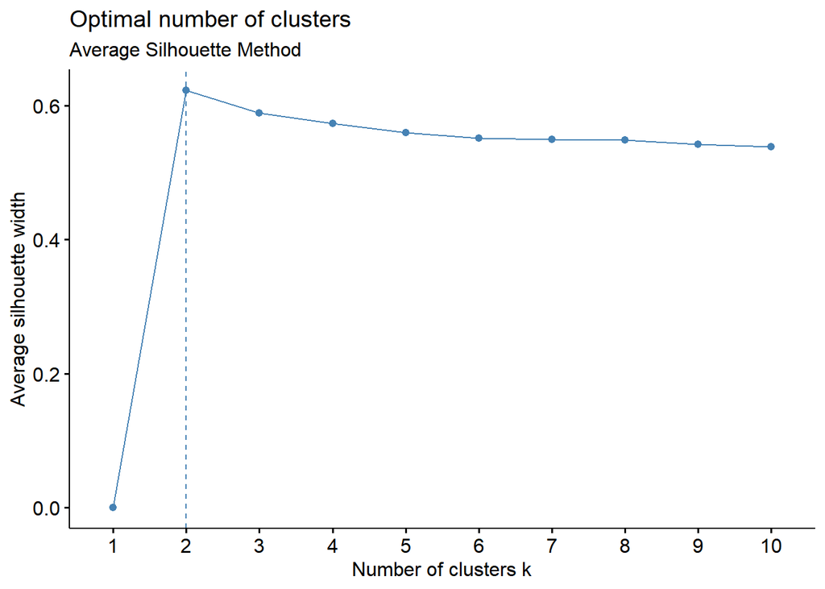

```r
# no scaling ---------------------------------------------------------

#-----------DETERMINE THE OPTIMAL NUMBER OF CLUSTERS------------------
# Average Silhouette Method ------------------------------------------
# automatic plot with package factoextra
factoextra::fviz_nbclust(trainData[,1:10], FUNcluster = kmeans, method = "silhouette") +
  labs(subtitle = "Average Silhouette Method")
```

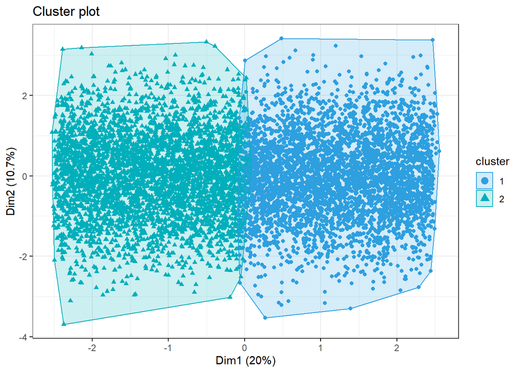

```r
# k = 2 based on Avg Silhouette Method

#-----------------------CLUSTERING USING K-MEANS----------------------
km <- kmeans(trainData[,1:10], centers = 2, nstart = 25)

#---------------------------PLOT THE CLUSTERS-------------------------
factoextra::fviz_cluster(km, data = trainData[,1:10],
             palette = c("#2E9FDF", "#00AFBB", "#E7B800"),
             geom = "point",
             ellipse.type = "convex",
             ggtheme = theme_bw()
)
```

```r
#---------------------------CLUSTER VALIDATION------------------------
# External validation using Rand Index
# Compute the Corrected Rand Index
(cri_km <- external_validation(as.numeric(trainData$category), km$cluster,
                          method = "adjusted_rand_index", summary_stats = T))
```

```
##
## ----------------------------------------
## purity                         : 0.8735
## entropy                        : 0.9998
## normalized mutual information  : 2e-04
## variation of information       : 1.5475
## normalized var. of information : 0.9999
## ----------------------------------------
## specificity                    : 0.5002
## sensitivity                    : 0.5
## precision                      : 0.779
## recall                         : 0.5
## F-measure                      : 0.6091
## ----------------------------------------
## accuracy OR rand-index         : 0.5
## adjusted-rand-index            : 1e-04
## jaccard-index                  : 0.4379
## fowlkes-mallows-index          : 0.6241
## mirkin-metric                  : 31993502
## ----------------------------------------
```

```
## [1] 0.0001223948
```

```r
# Compute the Variation of Information
(vi_km <- external_validation(as.numeric(trainData$category), km$cluster,
                          method = "var_info", summary_stats = F))
```

```
## [1] 1.547451
```

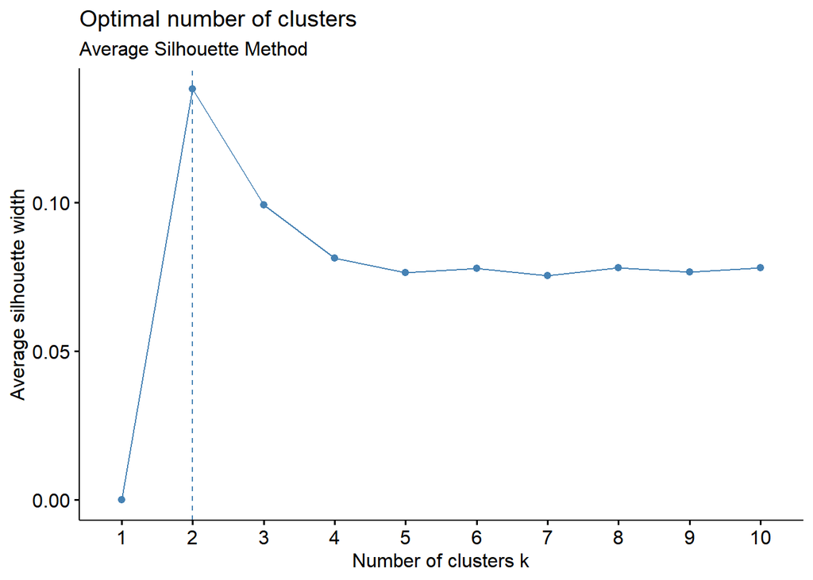

```r
# scaling ------------------------------------------------------------
A2scaled <- scale(trainData[,1:10])

#-----------DETERMINE THE OPTIMAL NUMBER OF CLUSTERS------------------
# Average Silhouette Method ------------------------------------------
# automatic plot  with package factoextra
factoextra::fviz_nbclust(A2scaled, kmeans, method = "silhouette") +
  labs(subtitle = "Average Silhouette Method")
```

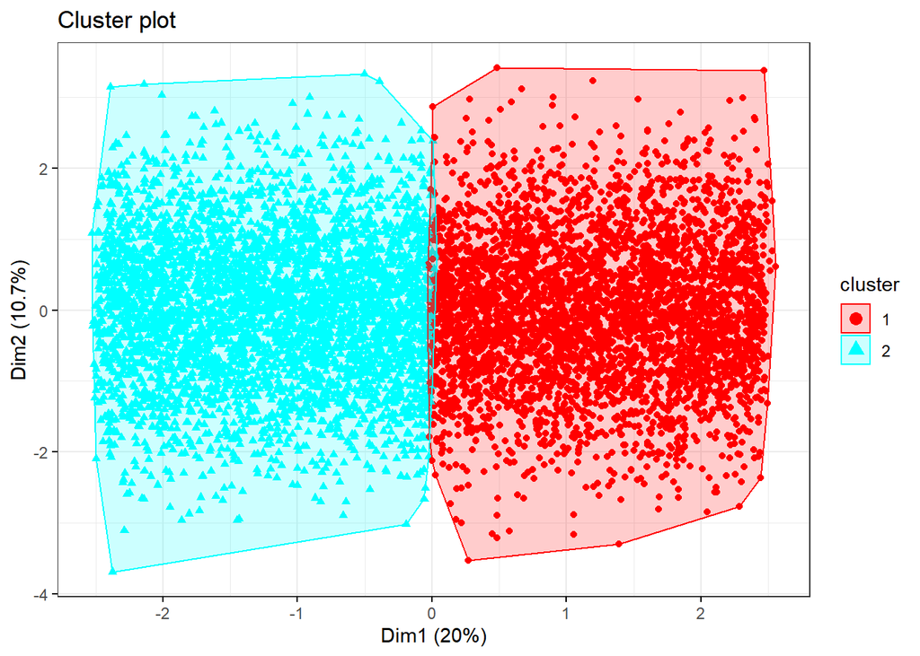

```r
# k = 2 based on Avg Silhouette Method

#-----------------------CLUSTERING USING K-MEANS----------------------
km1 <- kmeans(A2scaled, centers = 2, nstart = 25)

#---------------------------PLOT THE CLUSTERS-------------------------
factoextra::fviz_cluster(km1, data = A2scaled,
             palette = c(rainbow(2)),
             geom = "point",
             ellipse.type = "convex",
             ggtheme = theme_bw()
)
```

```r
#---------------------------CLUSTER VALIDATION------------------------
# External validation using Rand Index
# Compute the Corrected Rand Index
(cri_km1 <- external_validation(as.numeric(trainData$category), km1$cluster,
                          method = "adjusted_rand_index", summary_stats = T))
```

```
##
## ----------------------------------------
## purity                         : 0.8735
## entropy                        : 0.9999
## normalized mutual information  : 1e-04
## variation of information       : 1.5475
## normalized var. of information : 0.9999
## ----------------------------------------
## specificity                    : 0.5001
## sensitivity                    : 0.5
## precision                      : 0.779
## recall                         : 0.5
## F-measure                      : 0.6091
## ----------------------------------------
## accuracy OR rand-index         : 0.5
## adjusted-rand-index            : 1e-04
## jaccard-index                  : 0.4379
## fowlkes-mallows-index          : 0.6241
## mirkin-metric                  : 31995392
## ----------------------------------------
```

```
## [1] 7.480055e-05
```

```r
# Compute the Variation of Information
(vi_km1 <- external_validation(as.numeric(trainData$category), km1$cluster,
                          method = "var_info", summary_stats = F))
```

```
## [1] 1.54752
```

```r
# CONCLUSION : the best model for k-Means algorithm is the one with unscaled data because it has higher Corrected Rand Index of 0.0001223948 and lower Variation of Information of 1.547451
```

### 0.5.2 Clustering Algorithm 2 (Model-based Clustering)

```r
# set seed
set.seed(Rand)

# no scaling ---------------------------------------------------------
#-----------------------CLUSTERING USING MCLUST-----------------------
mb <- Mclust(trainData[,1:10], 2)
summary(mb)
```

```
## ----------------------------------------------------
## Gaussian finite mixture model fitted by EM algorithm
## ----------------------------------------------------
##
## Mclust EEE (ellipsoidal, equal volume, shape and orientation) model with 2
## components:
##
##  log-likelihood    n df      BIC      ICL
##       -520014.5 8000 76 -1040712 -1042182
##
## Clustering table:
##    1    2
## 4033 3967
```

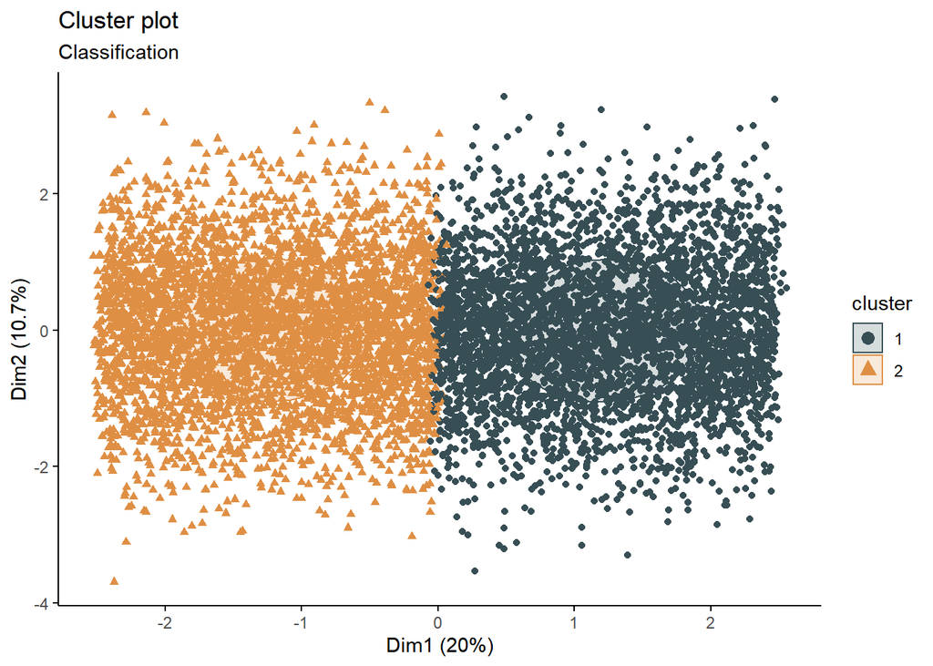

```r
#---------------------------PLOT THE CLUSTERS-------------------------
# Visualizing scaled 2-cluster model
fviz_mclust(mb, "classification", geom = "point",pointsize = 1.5, palette = "jama")
```

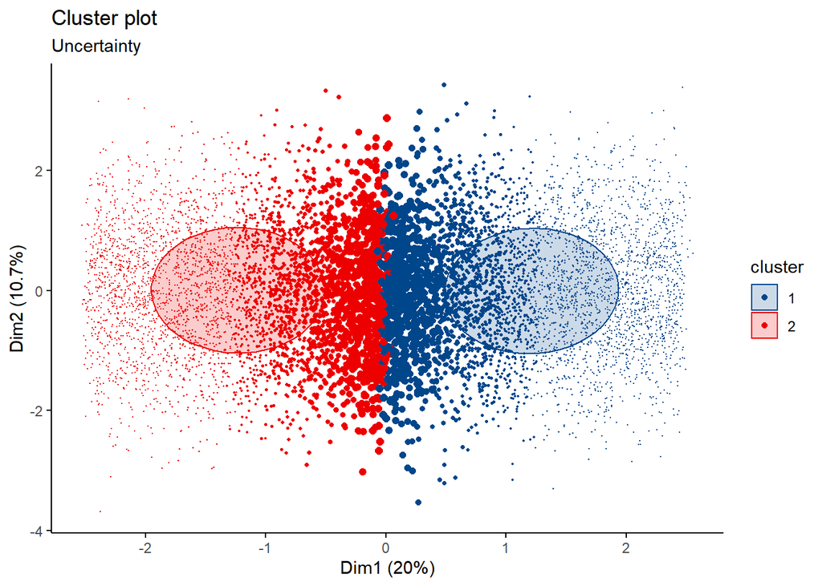

```r
fviz_mclust(mb, "uncertainty", palette = "lancet")
```

```r
#---------------------------CLUSTER VALIDATION------------------------
# External validation using Rand Index
# Compute the Corrected Rand Index
(cri_mb <- external_validation(as.numeric(trainData$category), mb$classification,
                          method = "adjusted_rand_index", summary_stats = T))
```

```
##
## ----------------------------------------
## purity                         : 0.8735
## entropy                        : 0.9998
## normalized mutual information  : 2e-04
## variation of information       : 1.5474
## normalized var. of information : 0.9999
## ----------------------------------------
## specificity                    : 0.5002
## sensitivity                    : 0.5
## precision                      : 0.779
## recall                         : 0.5
## F-measure                      : 0.6091
## ----------------------------------------
## accuracy OR rand-index         : 0.5001
## adjusted-rand-index            : 1e-04
## jaccard-index                  : 0.4379
## fowlkes-mallows-index          : 0.6241
## mirkin-metric                  : 31992558
## ----------------------------------------
```

```
## [1] 0.000139344
```

```r
# Compute the Variation of Information
(vi_mb <- external_validation(as.numeric(trainData$category), mb$classification,
                          method = "var_info", summary_stats = F))
```

```
## [1] 1.547442
```

```r
# with scaling -------------------------------------------------------
#-----------------------CLUSTERING USING MCLUST-----------------------
A2scaled <- scale(trainData[,1:10])

mb1 <- Mclust(A2scaled, 2)
summary(mb1)
```

```
## ----------------------------------------------------
## Gaussian finite mixture model fitted by EM algorithm
## ----------------------------------------------------
##
## Mclust EEE (ellipsoidal, equal volume, shape and orientation) model with 2
## components:
##
##  log-likelihood    n df       BIC       ICL
##       -57609.66 8000 76 -115902.4 -117349.1
##
## Clustering table:
##    1    2
## 4045 3955
```

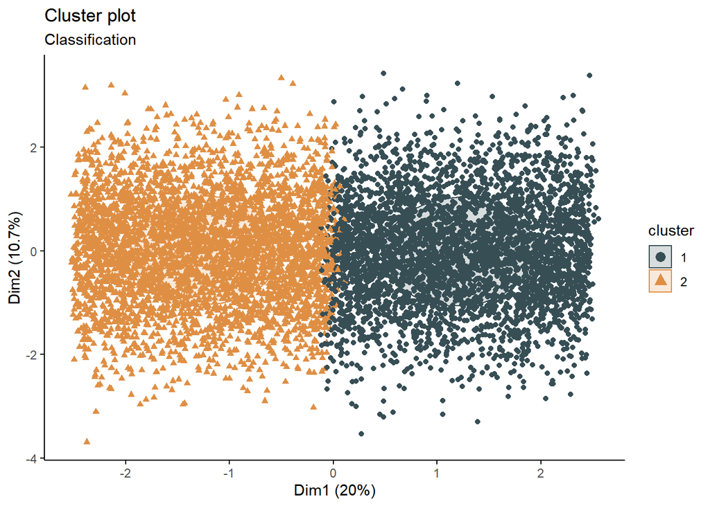

```r
# RESULT : the better model is the mb1 with scaled condition and two clusters because the BIC value is higher (closer to zero)

#---------------------------PLOT THE CLUSTERS-------------------------
# Visualizing scaled 2-cluster model
fviz_mclust(mb1, "classification", geom = "point",pointsize = 1.5, palette = "jama")
```

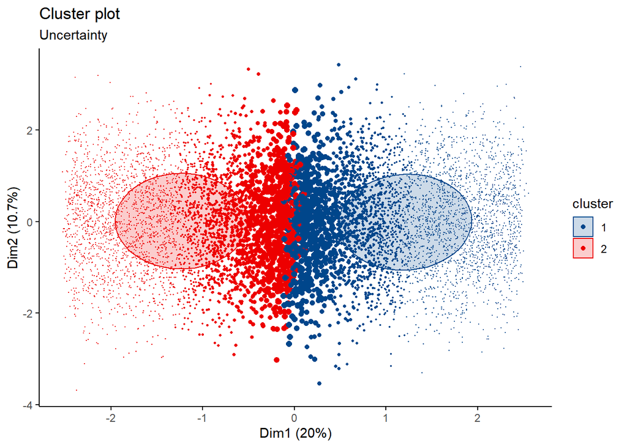

```r
fviz_mclust(mb1, "uncertainty", palette = "lancet")
```

```r
#---------------------------CLUSTER VALIDATION------------------------
# External validation using Rand Index
# Compute the Corrected Rand Index
(cri_mb1 <- external_validation(as.numeric(trainData$category), mb1$classification,
                          method = "adjusted_rand_index", summary_stats = T))
```

```
##
## ----------------------------------------
## purity                         : 0.8735
## entropy                        : 0.9998
## normalized mutual information  : 2e-04
## variation of information       : 1.5474
## normalized var. of information : 0.9999
## ----------------------------------------
## specificity                    : 0.5002
## sensitivity                    : 0.5001
## precision                      : 0.7791
## recall                         : 0.5001
## F-measure                      : 0.6091
## ----------------------------------------
## accuracy OR rand-index         : 0.5001
## adjusted-rand-index            : 2e-04
## jaccard-index                  : 0.4379
## fowlkes-mallows-index          : 0.6242
## mirkin-metric                  : 31990478
## ----------------------------------------
```

```
## [1] 0.0001717123
```

```r
# Compute the Variation of Information
(vi_mb1 <- external_validation(as.numeric(trainData$category), mb1$classification,
                          method = "var_info", summary_stats = F))
```

```
## [1] 1.547414
```

```r
# CONCLUSION : the best model for Model-based Clustering algorithm is the one with scaled data because it has higher BIC value (closer to zero), higher Corrected Rand Index of 0.0001717123, and lower Variation of Information of 1.547414
```

### 0.5.3 Comparing the 2 Clustering Algorithms

```r
#-------------------------------k-Means-------------------------------
(cri_km <- external_validation(as.numeric(trainData$category), km$cluster,
                          method = "adjusted_rand_index", summary_stats = T))
```

```
##
## ----------------------------------------
## purity                         : 0.8735
## entropy                        : 0.9998
## normalized mutual information  : 2e-04
## variation of information       : 1.5475
## normalized var. of information : 0.9999
## ----------------------------------------
## specificity                    : 0.5002
## sensitivity                    : 0.5
## precision                      : 0.779
## recall                         : 0.5
## F-measure                      : 0.6091
## ----------------------------------------
## accuracy OR rand-index         : 0.5
## adjusted-rand-index            : 1e-04
## jaccard-index                  : 0.4379
## fowlkes-mallows-index          : 0.6241
## mirkin-metric                  : 31993502
## ----------------------------------------
```

```
## [1] 0.0001223948
```

```r
# The accuracy of k-means algorithm is 0.5

#------------------------Model-based Clustering-----------------------
(cri_mb1 <- external_validation(as.numeric(trainData$category), mb1$classification,
                          method = "adjusted_rand_index", summary_stats = T))
```

```
##
## ----------------------------------------
## purity                         : 0.8735
## entropy                        : 0.9998
## normalized mutual information  : 2e-04
## variation of information       : 1.5474
## normalized var. of information : 0.9999
## ----------------------------------------
## specificity                    : 0.5002
## sensitivity                    : 0.5001
## precision                      : 0.7791
## recall                         : 0.5001
## F-measure                      : 0.6091
## ----------------------------------------
## accuracy OR rand-index         : 0.5001
## adjusted-rand-index            : 2e-04
## jaccard-index                  : 0.4379
## fowlkes-mallows-index          : 0.6242
## mirkin-metric                  : 31990478
## ----------------------------------------
```

```
## [1] 0.0001717123
```

```r
# The accuracy of Model-based Clustering algorithm is 0.5001

#------------------------------COMPARING------------------------------
clust_algo <- c("k-Means", "Model-based Clustering")
cri <- c(cri_km, cri_mb1)
vi <- c(vi_km, vi_mb1)
(algo_table1 <- data.frame(clust_algo, cri, vi))
```

```
##               clust_algo          cri       vi
## 1                k-Means 0.0001223948 1.547451
## 2 Model-based Clustering 0.0001717123 1.547414
```

```r
# CONCLUSION : the best algorithm for clustering A2 data is the Model-based Clustering algorithm with the highest accuracy of 0.5001 or 50.01%, a higher corrected rand index of 0.0001717123, and lower variation of information of 1.547414
```

## 0.6 Data Classification : Using 2 Algorithms

### 0.6.1 Classification Algorithm 1 (Naive Bayes)

```r
#---------------------------NBC for category--------------------------
nb_model <- NaiveBayes(category ~ ., data = trainData) #NB classifier model
nb_pred <- predict(nb_model, testData) #test model to data testing

#--------------------Naive Bayes' Model Evaluation--------------------
# Making the Confusion Matrix
nb_table <- table(nb_pred$class, testData$category) #tabulate class
(nb_cm <- caret::confusionMatrix(nb_table)) #creating Confusion Matrix
```

```
## Confusion Matrix and Statistics
##
##
##          Basic Luxury
##   Basic   1747    253
##   Luxury     0      0
##
##                Accuracy : 0.8735
##                  95% CI : (0.8581, 0.8878)
##     No Information Rate : 0.8735
##     P-Value [Acc > NIR] : 0.5168
##
##                   Kappa : 0
##
##  Mcnemar's Test P-Value : <2e-16
##
##             Sensitivity : 1.0000
##             Specificity : 0.0000
##          Pos Pred Value : 0.8735
##          Neg Pred Value :    NaN
##              Prevalence : 0.8735
##          Detection Rate : 0.8735
##    Detection Prevalence : 1.0000
##       Balanced Accuracy : 0.5000
##
##        'Positive' Class : Basic
##
```

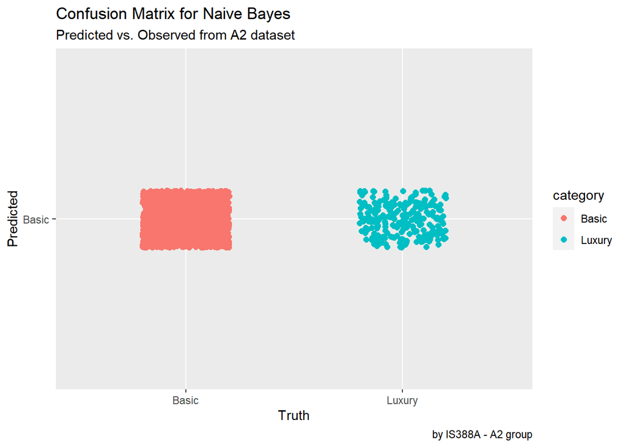

```r
# Plot the Confusion Matrix
testData$nb_pred <- nb_pred$class
ggplot(testData, aes(category, nb_pred, color = category)) +
  geom_jitter(width = 0.2, height = 0.1, size=2) +
  labs(title = "Confusion Matrix for Naive Bayes",
       subtitle = "Predicted vs. Observed from A2 dataset",
       y = "Predicted", x = "Truth", caption = "by IS388A - A2 group")
```

```r
# CONCLUSION : Naive Bayes classification algorithm has an accuracy of 0.8735, sensitivity of 1, and specificity of 0
```

### 0.6.2 Algorithm 2 (Random Forest)

```r
# Making Random Forest model -----------------------------------------
rf_model <- randomForest(category ~ ., data = trainData, importance = TRUE)
print(rf_model)
```

```
##
## Call:
##  randomForest(formula = category ~ ., data = trainData, importance = TRUE)
##                Type of random forest: classification
##                      Number of trees: 500
## No. of variables tried at each split: 3
##
##         OOB estimate of  error rate: 12.64%
## Confusion matrix:
##        Basic Luxury class.error
## Basic   6988      0   0.0000000
## Luxury  1011      1   0.9990119
```

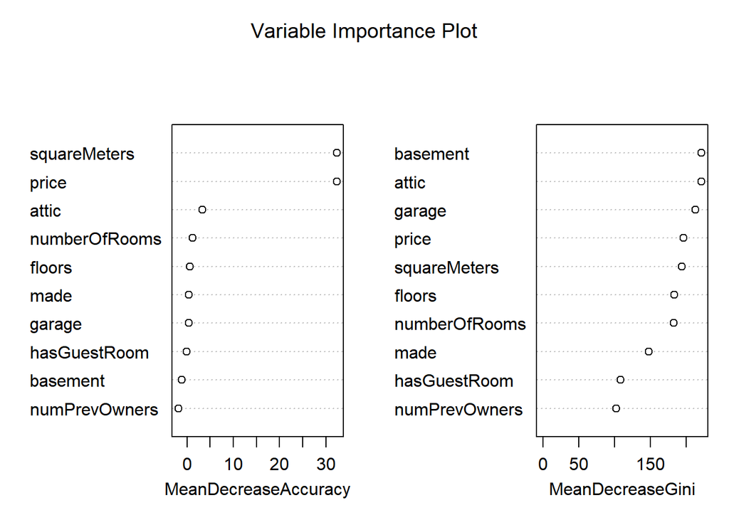

```r
# Variable Importance Plot for RF Model ------------------------------
varImpPlot(rf_model, main = "Variable Importance Plot")
```

```r
# Making the prediction using data testing ---------------------------
rf_pred <- predict(rf_model, testData)

# Making the Confusion Matrix ----------------------------------------
(rf_cm <- caret::confusionMatrix(rf_pred, testData$category))
```

```
## Confusion Matrix and Statistics
##
##           Reference
## Prediction Basic Luxury
##     Basic   1747     39
##     Luxury     0    214
##
##                Accuracy : 0.9805
##                  95% CI : (0.9734, 0.9861)
##     No Information Rate : 0.8735
##     P-Value [Acc > NIR] : < 2.2e-16
##
##                   Kappa : 0.9055
##
##  Mcnemar's Test P-Value : 1.166e-09
##
##             Sensitivity : 1.0000
##             Specificity : 0.8458
##          Pos Pred Value : 0.9782
##          Neg Pred Value : 1.0000
##              Prevalence : 0.8735
##          Detection Rate : 0.8735
##    Detection Prevalence : 0.8930
##       Balanced Accuracy : 0.9229
##
##        'Positive' Class : Basic
##
```

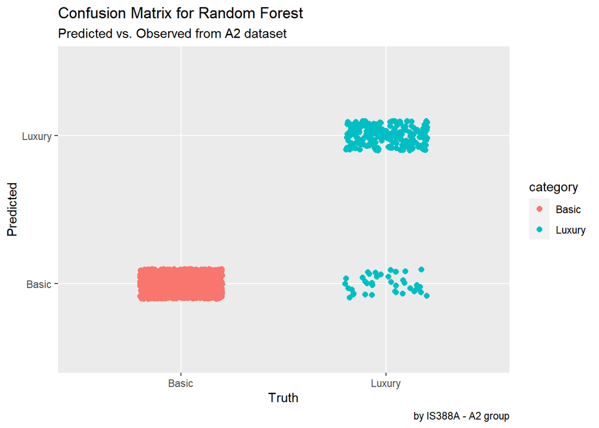

```r
# Plot the Confusion Matrix ------------------------------------------
testData$rf_pred <- rf_pred
ggplot(testData, aes(category, rf_pred, color = category)) +
  geom_jitter(width = 0.2, height = 0.1, size=2) +
  labs(title = "Confusion Matrix for Random Forest",
       subtitle = "Predicted vs. Observed from A2 dataset",
       y = "Predicted", x = "Truth", caption = "by IS388A - A2 group")
```

```r
# CONCLUSION : Random Forest classification algorithm has an accuracy of 0.9805, sensitivity of 1, and specificity of 0.8458
```

### 0.6.3 Comparing the 2 Classification Algorithms

```r
#-----------------------------Naive Bayes-----------------------------
nb_cm
```

```
## Confusion Matrix and Statistics
##
##
##          Basic Luxury
##   Basic   1747    253
##   Luxury     0      0
##
##                Accuracy : 0.8735
##                  95% CI : (0.8581, 0.8878)
##     No Information Rate : 0.8735
##     P-Value [Acc > NIR] : 0.5168
##
##                   Kappa : 0
##
##  Mcnemar's Test P-Value : <2e-16
##
##             Sensitivity : 1.0000
##             Specificity : 0.0000
##          Pos Pred Value : 0.8735
##          Neg Pred Value :    NaN
##              Prevalence : 0.8735
##          Detection Rate : 0.8735
##    Detection Prevalence : 1.0000
##       Balanced Accuracy : 0.5000
##
##        'Positive' Class : Basic
##
```

```r
#----------------------------Random Forest----------------------------
rf_cm
```

```
## Confusion Matrix and Statistics
##
##           Reference
## Prediction Basic Luxury
##     Basic   1747     39
##     Luxury     0    214
##
##                Accuracy : 0.9805
##                  95% CI : (0.9734, 0.9861)
##     No Information Rate : 0.8735
##     P-Value [Acc > NIR] : < 2.2e-16
##
##                   Kappa : 0.9055
##
##  Mcnemar's Test P-Value : 1.166e-09
##
##             Sensitivity : 1.0000
##             Specificity : 0.8458
##          Pos Pred Value : 0.9782
##          Neg Pred Value : 1.0000
##              Prevalence : 0.8735
##          Detection Rate : 0.8735
##    Detection Prevalence : 0.8930
##       Balanced Accuracy : 0.9229
##
##        'Positive' Class : Basic
##
```

```r
#------------------------------COMPARING------------------------------
classi_algo <- c("Naive Bayes", "Random Forest")
accuracy <- c(nb_cm$overall[1], rf_cm$overall[1])
kappa <- c(nb_cm$overall[2], rf_cm$overall[2])
sensitivity <- c(nb_cm$byClass[1], rf_cm$byClass[1])
specificity <- c(nb_cm$byClass[2], rf_cm$byClass[2])
precision <- c(nb_cm$byClass[5], rf_cm$byClass[5])

(algo_table2 <- data.frame(classi_algo, accuracy, kappa, sensitivity, specificity, precision))
```

```
##     classi_algo accuracy     kappa sensitivity specificity precision
## 1   Naive Bayes   0.8735 0.0000000           1   0.0000000 0.8735000
## 2 Random Forest   0.9805 0.9055365           1   0.8458498 0.9781635
```

```r
# CONCLUSION : the best algorithm for classifying A2 dataset is Random Forest algorithm with the highest accuracy of 0.9805, kappa value of 0.9055, sensitivity of 1, specificity of 0.8458, and precision of 0.9781
```